# **Project: Marketing Campaign Analysis**

# **Marks: 60**

Welcome to the project on Foundations for Data Science. In this project, we aim to analyze the marketing data and address some key business questions.

## **Context**

Marketing Analytics broadly refers to the practice of using analytical methods and techniques to understand the effectiveness of various marketing activities and deploy data-driven decisions to optimize for ROI on conversion rates. It typically involves analyzing various metrics around customer engagement with various marketing activities including but not limited to, ATL (above the line) marketing activities, BTL (below the line) campaigns, and targeting personalized offers. Typically the variables of interest are customer profile, campaign conversion rates, and costs associated with various marketing channels. These can generate valuable insights that can help an organization form better marketing strategies, optimize/innovate on delivery, and achieve overall growth.

## **Objective**

Company 'All You Need' has hired you as a Data Scientist and you've been told by the Chief Marketing Officer that recent marketing campaigns have not been as effective as they were expected to be and the conversion rate is very low. Your task is to analyze the related data, understand the problem, and identify key insights and recommendations for the CMO to potentially implement.

The data set marketing_data.csv consists of 2,240 customers of the company with information on:

- Campaign successes/failures
- Product preferences
- Channel performances
- Customer profiles based on the spending habits

## **Data Dictionary**

- ID: Unique ID of each customer
- Year_Birth: Age of the customer
- Education: Customer's level of education
- Marital_Status: Customer's marital status
- Kidhome: Number of small children in customer's household
- Teenhome: Number of teenagers in customer's household
- Income: Customer's yearly household income
- Recency: Number of days since the last purchase
- MntFishProducts: The amount spent on fish products in the last 2 years
- MntMeatProducts: The amount spent on meat products in the last 2 years
- MntFruits: The amount spent on fruits products in the last 2 years
- MntSweetProducts: Amount spent on sweet products in the last 2 years
- MntWines: The amount spent on wine products in the last 2 years
- MntGoldProds: The amount spent on gold products in the last 2 years
- NumDealsPurchases: Number of purchases made with discount
- NumCatalogPurchases: Number of purchases made using catalog (buying goods to be shipped through the mail)
- NumStorePurchases: Number of purchases made directly in stores
- NumWebPurchases: Number of purchases made through the company's website
- NumWebVisitsMonth: Number of visits to the company's website in the last month
- AcceptedCmp1: 1 if customer accepted the offer in the first campaign, 0 otherwise
- AcceptedCmp2: 1 if customer accepted the offer in the second campaign, 0 otherwise
- AcceptedCmp3: 1 if customer accepted the offer in the third campaign, 0 otherwise
- AcceptedCmp4: 1 if customer accepted the offer in the fourth campaign, 0 otherwise
- AcceptedCmp5: 1 if customer accepted the offer in the fifth campaign, 0 otherwise
- AcceptedCmp6: 1 if customer accepted the offer in the last campaign, 0 otherwise
- Complain: 1 If the customer complained in the last 2 years, 0 otherwise
- Country: The country customer belongs to

## **Importing the necessary libraries and overview of the dataset**

```python
# Library to suppress warnings or deprecation notes
import warnings
warnings.filterwarnings('ignore')

# Libraries to help with reading and manipulating data
import numpy as np

import pandas as pd

# Libraries to help with data visualization
import matplotlib.pyplot as plt
%matplotlib inline

import seaborn as sns
```

### **Loading the dataset**

```python
# loading the datset

df = pd.read_csv('Marketing+Data.csv')

df.head()
```

|  | ID | Year_Birth | Education | Marital_Status | Income | Kidhome | Teenhome | Recency | MntWines | MntFruits | ... | NumStorePurchases | NumWebVisitsMonth | AcceptedCmp1 | AcceptedCmp2 | AcceptedCmp3 | AcceptedCmp4 | AcceptedCmp5 | AcceptedCmp6 | Complain | Country |
| --- | --- | --- | --- | --- | --- | --- | --- | --- | --- | --- | --- | --- | --- | --- | --- | --- | --- | --- | --- | --- | --- |
| 0 | 1826 | 1970 | Graduation | Divorced | 84835.0 | 0 | 0 | 0 | 189 | 104 | ... | 6 | 1 | 0 | 1 | 0 | 0 | 0 | 0 | 0 | SP |
| 1 | 1 | 1961 | Graduation | Single | 57091.0 | 0 | 0 | 0 | 464 | 5 | ... | 7 | 5 | 0 | 1 | 0 | 0 | 0 | 1 | 0 | CA |
| 2 | 10476 | 1958 | Graduation | Married | 67267.0 | 0 | 1 | 0 | 134 | 11 | ... | 5 | 2 | 0 | 0 | 0 | 0 | 0 | 0 | 0 | US |
| 3 | 1386 | 1967 | Graduation | Together | 32474.0 | 1 | 1 | 0 | 10 | 0 | ... | 2 | 7 | 0 | 0 | 0 | 0 | 0 | 0 | 0 | AUS |
| 4 | 5371 | 1989 | Graduation | Single | 21474.0 | 1 | 0 | 0 | 6 | 16 | ... | 2 | 7 | 1 | 1 | 0 | 0 | 0 | 0 | 0 | SP |

5 rows × 27 columns

### **Checking the info of the dataset**

```python
# Checking the info

df.info()
```

```
<class 'pandas.core.frame.DataFrame'>
RangeIndex: 2240 entries, 0 to 2239
Data columns (total 27 columns):
 #   Column               Non-Null Count  Dtype
---  ------               --------------  -----
 0   ID                   2240 non-null   int64
 1   Year_Birth           2240 non-null   int64
 2   Education            2240 non-null   object
 3   Marital_Status       2240 non-null   object
 4   Income               2216 non-null   float64
 5   Kidhome              2240 non-null   int64
 6   Teenhome             2240 non-null   int64
 7   Recency              2240 non-null   int64
 8   MntWines             2240 non-null   int64
 9   MntFruits            2240 non-null   int64
```

[output cut: 19 more lines]

**Observations:**

- There are a total of **27 columns and 2,240 observations** in the dataset.
- We can see that the Income column has less than 2,240 non-null values, i.e., **the Income column has missing values**. We'll explore this further.

### **Let's check the percentage of missing values for the Income column**

```python
# % null values in the Income column

(df.isnull().sum()/df.shape[0] * 100)['Income']
```

```
1.0714285714285714
```

**Observation:**

- The Income column has ~1.07% missing values.

### **Let's create a list for numerical columns in the dataset and check the summary statistics**

### **Question 1: Find the summary statistics for numerical columns using the describe function and write your observations. (4 Marks)**

```python
# num_cols contain numerical varibales
num_cols = ['Year_Birth', 'Income', 'Recency', 'MntWines', 'MntFruits',
       'MntMeatProducts', 'MntFishProducts', 'MntSweetProducts',
       'MntGoldProds', 'NumDealsPurchases', 'NumWebPurchases',
       'NumCatalogPurchases', 'NumStorePurchases', 'NumWebVisitsMonth', 'Kidhome',
       'Teenhome']
```

```python
# Printing descriptive statistics of numerical columns

# Uncomment the following code and fill in the blanks
df[num_cols].describe().T
```

|  | count | mean | std | min | 25% | 50% | 75% | max |
| --- | --- | --- | --- | --- | --- | --- | --- | --- |
| Year_Birth | 2240.0 | 1968.805804 | 11.984069 | 1893.0 | 1959.00 | 1970.0 | 1977.00 | 1996.0 |
| Income | 2216.0 | 52247.251354 | 25173.076661 | 1730.0 | 35303.00 | 51381.5 | 68522.00 | 666666.0 |
| Recency | 2240.0 | 49.109375 | 28.962453 | 0.0 | 24.00 | 49.0 | 74.00 | 99.0 |
| MntWines | 2240.0 | 303.935714 | 336.597393 | 0.0 | 23.75 | 173.5 | 504.25 | 1493.0 |
| MntFruits | 2240.0 | 26.302232 | 39.773434 | 0.0 | 1.00 | 8.0 | 33.00 | 199.0 |
| MntMeatProducts | 2240.0 | 166.950000 | 225.715373 | 0.0 | 16.00 | 67.0 | 232.00 | 1725.0 |
| MntFishProducts | 2240.0 | 37.525446 | 54.628979 | 0.0 | 3.00 | 12.0 | 50.00 | 259.0 |
| MntSweetProducts | 2240.0 | 27.062946 | 41.280498 | 0.0 | 1.00 | 8.0 | 33.00 | 263.0 |
| MntGoldProds | 2240.0 | 44.021875 | 52.167439 | 0.0 | 9.00 | 24.0 | 56.00 | 362.0 |
| NumDealsPurchases | 2240.0 | 2.325000 | 1.932238 | 0.0 | 1.00 | 2.0 | 3.00 | 15.0 |
| NumWebPurchases | 2240.0 | 4.084821 | 2.778714 | 0.0 | 2.00 | 4.0 | 6.00 | 27.0 |
| NumCatalogPurchases | 2240.0 | 2.662054 | 2.923101 | 0.0 | 0.00 | 2.0 | 4.00 | 28.0 |
| NumStorePurchases | 2240.0 | 5.790179 | 3.250958 | 0.0 | 3.00 | 5.0 | 8.00 | 13.0 |
| NumWebVisitsMonth | 2240.0 | 5.316518 | 2.426645 | 0.0 | 3.00 | 6.0 | 7.00 | 20.0 |
| Kidhome | 2240.0 | 0.444196 | 0.538398 | 0.0 | 0.00 | 0.0 | 1.00 | 2.0 |
| Teenhome | 2240.0 | 0.506250 | 0.544538 | 0.0 | 0.00 | 0.0 | 1.00 | 2.0 |

**Observations:**

- The Income column only has count of 2216, instead of 2240 like all the other rows, it is missing values.
- Some of the std looks very high, possibly an outlier

### Let's create a list for categorical columns in the dataset and check the count of each category

```python
# cat_cols contain categorical variables
cat_cols = ['Education', 'Marital_Status', 'AcceptedCmp3', 'AcceptedCmp4', 'AcceptedCmp5', 'AcceptedCmp1',
       'AcceptedCmp2', 'AcceptedCmp6', 'Complain', 'Country']
```

```python
# Printing the count of each unique value in each column

for column in cat_cols:
    print(df[column].value_counts(normalize = True))

    print("-" * 40)
```

```
Graduation    0.503125
PhD           0.216964
Master        0.165179
2n Cycle      0.090625
Basic         0.024107
Name: Education, dtype: float64
----------------------------------------
Married     0.385714
Together    0.258929
Single      0.214286
Divorced    0.103571
Widow       0.034375
Alone       0.001339
Absurd      0.000893
YOLO        0.000893
Name: Marital_Status, dtype: float64
----------------------------------------
0    0.927232
1    0.072768
Name: AcceptedCmp3, dtype: float64
----------------------------------------
0    0.935714
1    0.064286
Name: AcceptedCmp4, dtype: float64
----------------------------------------
0    0.925446
1    0.074554
Name: AcceptedCmp5, dtype: float64
----------------------------------------
0    0.927232
1    0.072768
Name: AcceptedCmp1, dtype: float64
----------------------------------------
0    0.850893
1    0.149107
Name: AcceptedCmp2, dtype: float64
----------------------------------------
0    0.986607
1    0.013393
Name: AcceptedCmp6, dtype: float64
----------------------------------------
0    0.990625
1    0.009375
Name: Complain, dtype: float64
----------------------------------------
SP     0.488839
SA     0.150446
CA     0.119643
AUS    0.071429
IND    0.066071
GER    0.053571
US     0.048661
ME     0.001339
Name: Country, dtype: float64
----------------------------------------
```

**Observations:**

## **Data Preprocessing and Exploratory Data Analysis**

In this section, we will first prepare our dataset for analysis.

- Fixing the categories
- Creating new columns as the total amount spent, total purchase made, total kids at home, and total accepted campaigns
- Dealing with missing values and outliers
- Extract the key insights from the data

### **Replacing the "2n Cycle" category with "Master" in Education and "Alone" with "Single" in Marital_Status and "Absurd" and "YOLO" categories with "Others" in Marital_Status**

```python
# Replacing 2n Cycle with Master

df["Education"].replace("2n Cycle", "Master", inplace = True)
```

```python
# Replacing Alone with Single

df["Marital_Status"].replace(["Alone",], "Single", inplace = True)
```

```python
# Replacing YOLO and Absurd with Others

df['Marital_Status'].replace(["Absurd", "YOLO"], "Others", inplace = True)
```

We have fixed the categories in the Marital_Status. Now, let's check the count of different categories for marital status.

```python
df.Marital_Status.value_counts()
```

```
Married     864
Together    580
Single      483
Divorced    232
Widow        77
Others        4
Name: Marital_Status, dtype: int64
```

**Observation:**

- The majority of customers belong to the married category, and the other category has only 4 observations.

### Creating new features from the existing features

```python
# Creating new features to get an overall picture of a customer, how much he/she has spent,
# The number of children he/she has, total number of campaigns accepted, etc.

# The total spending by a customer
spending_col = [col for col in df.columns if 'Mnt' in col]

df['Total_Spending'] = df[spending_col].sum(axis = 1)

# Total purchases made by a customer
platform_col = [col for col in df.columns if 'Purchases' in col]

df['Total_Purchase'] = df[platform_col].sum(axis = 1)

# Total number of childern
df['NumberofChildren'] = df['Kidhome'] + df['Teenhome']

# Total number of campaign accepted by a customer
campaigns_cols = [col for col in df.columns if 'Cmp' in col]

df['TotalCampaignsAcc'] = df[campaigns_cols].sum(axis = 1)
```

### **Let's check outliers for new variables - Total_Spending, Total_Purchase. Also, let's analyze the Year_Birth column as we observed above that it had a minimum value of 1893.**

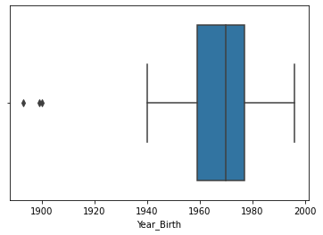

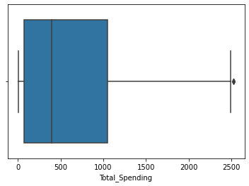

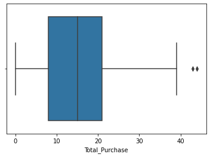

```python
# Plotting boxplot for Year_Birth, Total_Spending, Total_Purchase

cols = ['Year_Birth', 'Total_Spending', 'Total_Purchase']

for i in cols:
    sns.boxplot(x = df[i])
    plt.show()
```

**Observations:**

- The birth year is reported as <=1900 for some users, while the current year is 2022. It's very unlikely that the person is alive. It may be a reporting error.
- There are some outliers in total spending and total purchase.
- The observations marked as outliers are very closed to the upper whisker and some extreme points can be expected for variables like total spending. We can leave these outliers untreated.

Let's check the number of observations for which the year of birth is less than 1900.

```python
df[df['Year_Birth'] < 1900]
```

|  | ID | Year_Birth | Education | Marital_Status | Income | Kidhome | Teenhome | Recency | MntWines | MntFruits | ... | AcceptedCmp3 | AcceptedCmp4 | AcceptedCmp5 | AcceptedCmp6 | Complain | Country | Total_Spending | Total_Purchase | NumberofChildren | TotalCampaignsAcc |
| --- | --- | --- | --- | --- | --- | --- | --- | --- | --- | --- | --- | --- | --- | --- | --- | --- | --- | --- | --- | --- | --- |
| 513 | 11004 | 1893 | 2n Cycle | Single | 60182.0 | 0 | 1 | 23 | 8 | 0 | ... | 0 | 0 | 0 | 0 | 0 | SA | 22 | 4 | 1 | 0 |
| 827 | 1150 | 1899 | PhD | Together | 83532.0 | 0 | 0 | 36 | 755 | 144 | ... | 1 | 0 | 0 | 0 | 0 | SP | 1853 | 15 | 0 | 1 |

2 rows × 31 columns

**Observation:**

- There are only 2 observations for which the birth year is less than 1900. We can drop these observations.

```python
# Keeping data for customers having birth year > 1900

df = df[df['Year_Birth'] > 1900]
```

### **Check the outliers and impute the missing values for the Income variable**

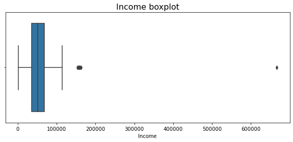

```python
# Plotting the boxplot for income

plt.figure(figsize = (10, 4))

sns.boxplot(df['Income'])

plt.title('Income boxplot', size = 16)

plt.show()
```

**Observations:**

- We can observe from the boxplot that there are some outliers in the income variable.
- Let's find the value at upper whisker to check how many observations are marked as outliers.

```python
# Calculating the upper whisker for the Income variable

Q1 = df.quantile(q = 0.25) # First quartile

Q3 = df.quantile(q = 0.75) # Third quartile

IQR = Q3 - Q1              # Inter Quartile Range

upper_whisker = (Q3 + 1.5 * IQR)['Income']   # Upper Whisker

print(upper_whisker)
```

```
118348.5
```

```python
# Checking the observations marked as outliers
df[df.Income > upper_whisker]
```

|  | ID | Year_Birth | Education | Marital_Status | Income | Kidhome | Teenhome | Recency | MntWines | MntFruits | ... | AcceptedCmp3 | AcceptedCmp4 | AcceptedCmp5 | AcceptedCmp6 | Complain | Country | Total_Spending | Total_Purchase | NumberofChildren | TotalCampaignsAcc |
| --- | --- | --- | --- | --- | --- | --- | --- | --- | --- | --- | --- | --- | --- | --- | --- | --- | --- | --- | --- | --- | --- |
| 325 | 4931 | 1977 | Graduation | Together | 157146.0 | 0 | 0 | 13 | 1 | 0 | ... | 0 | 0 | 0 | 0 | 0 | SA | 1730 | 28 | 0 | 0 |
| 497 | 1501 | 1982 | PhD | Married | 160803.0 | 0 | 0 | 21 | 55 | 16 | ... | 0 | 0 | 0 | 0 | 0 | US | 1717 | 44 | 0 | 0 |
| 527 | 9432 | 1977 | Graduation | Together | 666666.0 | 1 | 0 | 23 | 9 | 14 | ... | 0 | 0 | 0 | 0 | 0 | SA | 62 | 11 | 1 | 0 |
| 731 | 1503 | 1976 | PhD | Together | 162397.0 | 1 | 1 | 31 | 85 | 1 | ... | 0 | 0 | 0 | 0 | 0 | SP | 107 | 1 | 2 | 0 |
| 853 | 5336 | 1971 | Master | Together | 157733.0 | 1 | 0 | 37 | 39 | 1 | ... | 0 | 0 | 0 | 0 | 0 | SP | 59 | 2 | 1 | 0 |
| 1826 | 5555 | 1975 | Graduation | Divorced | 153924.0 | 0 | 0 | 81 | 1 | 1 | ... | 0 | 0 | 0 | 0 | 0 | SP | 6 | 0 | 0 | 0 |
| 1925 | 11181 | 1949 | PhD | Married | 156924.0 | 0 | 0 | 85 | 2 | 1 | ... | 0 | 0 | 0 | 0 | 0 | CA | 8 | 0 | 0 | 0 |
| 2204 | 8475 | 1973 | PhD | Married | 157243.0 | 0 | 1 | 98 | 20 | 2 | ... | 0 | 0 | 0 | 0 | 0 | IND | 1608 | 37 | 1 | 0 |

8 rows × 31 columns

**Observations:**

- We have only 8 observations with an income greater than the upper whisker.
- Only 3 observations (ID - 4931, 1501, 8475) out of 8 outliers have purchased more than 11 times in the last 2 years.
- Other 5 observations have a very less amount of total spending.

**Let's compare the summary statistics for these observations with observations on the other side of the upper whisker.**

```python
# Checking the summary statistics for observations marked as outliers
df[df.Income > upper_whisker].describe().T
```

|  | count | mean | std | min | 25% | 50% | 75% | max |
| --- | --- | --- | --- | --- | --- | --- | --- | --- |
| ID | 8.0 | 5989.250 | 3525.251308 | 1501.0 | 4074.00 | 5445.5 | 8714.25 | 11181.0 |
| Year_Birth | 8.0 | 1972.500 | 10.028531 | 1949.0 | 1972.50 | 1975.5 | 1977.00 | 1982.0 |
| Income | 8.0 | 221604.500 | 179850.404431 | 153924.0 | 157090.50 | 157488.0 | 161201.50 | 666666.0 |
| Kidhome | 8.0 | 0.375 | 0.517549 | 0.0 | 0.00 | 0.0 | 1.00 | 1.0 |
| Teenhome | 8.0 | 0.250 | 0.462910 | 0.0 | 0.00 | 0.0 | 0.25 | 1.0 |
| Recency | 8.0 | 48.625 | 33.687376 | 13.0 | 22.50 | 34.0 | 82.00 | 98.0 |
| MntWines | 8.0 | 26.500 | 30.798887 | 1.0 | 1.75 | 14.5 | 43.00 | 85.0 |
| MntFruits | 8.0 | 4.500 | 6.524678 | 0.0 | 1.00 | 1.0 | 5.00 | 16.0 |
| MntMeatProducts | 8.0 | 621.875 | 846.511402 | 1.0 | 7.25 | 17.0 | 1592.00 | 1725.0 |
| MntFishProducts | 8.0 | 4.250 | 5.650537 | 1.0 | 1.00 | 2.0 | 3.50 | 17.0 |
| MntSweetProducts | 8.0 | 1.250 | 0.886405 | 0.0 | 1.00 | 1.0 | 1.25 | 3.0 |
| MntGoldProds | 8.0 | 3.750 | 4.131759 | 1.0 | 1.00 | 1.5 | 5.00 | 12.0 |
| NumDealsPurchases | 8.0 | 4.250 | 6.777062 | 0.0 | 0.00 | 0.0 | 6.75 | 15.0 |
| NumWebPurchases | 8.0 | 0.500 | 1.069045 | 0.0 | 0.00 | 0.0 | 0.25 | 3.0 |
| NumCatalogPurchases | 8.0 | 9.875 | 13.484780 | 0.0 | 0.00 | 0.5 | 23.50 | 28.0 |
| NumStorePurchases | 8.0 | 0.750 | 1.035098 | 0.0 | 0.00 | 0.5 | 1.00 | 3.0 |
| NumWebVisitsMonth | 8.0 | 1.125 | 2.031010 | 0.0 | 0.00 | 0.5 | 1.00 | 6.0 |
| AcceptedCmp1 | 8.0 | 0.000 | 0.000000 | 0.0 | 0.00 | 0.0 | 0.00 | 0.0 |
| AcceptedCmp2 | 8.0 | 0.000 | 0.000000 | 0.0 | 0.00 | 0.0 | 0.00 | 0.0 |
| AcceptedCmp3 | 8.0 | 0.000 | 0.000000 | 0.0 | 0.00 | 0.0 | 0.00 | 0.0 |
| AcceptedCmp4 | 8.0 | 0.000 | 0.000000 | 0.0 | 0.00 | 0.0 | 0.00 | 0.0 |
| AcceptedCmp5 | 8.0 | 0.000 | 0.000000 | 0.0 | 0.00 | 0.0 | 0.00 | 0.0 |
| AcceptedCmp6 | 8.0 | 0.000 | 0.000000 | 0.0 | 0.00 | 0.0 | 0.00 | 0.0 |
| Complain | 8.0 | 0.000 | 0.000000 | 0.0 | 0.00 | 0.0 | 0.00 | 0.0 |
| Total_Spending | 8.0 | 662.125 | 848.380884 | 6.0 | 46.25 | 84.5 | 1635.25 | 1730.0 |
| Total_Purchase | 8.0 | 15.375 | 18.220377 | 0.0 | 0.75 | 6.5 | 30.25 | 44.0 |
| NumberofChildren | 8.0 | 0.625 | 0.744024 | 0.0 | 0.00 | 0.5 | 1.00 | 2.0 |
| TotalCampaignsAcc | 8.0 | 0.000 | 0.000000 | 0.0 | 0.00 | 0.0 | 0.00 | 0.0 |

```python
# Checking the summary statistics for observations not marked as outliers
df[df.Income < upper_whisker].describe().T
```

|  | count | mean | std | min | 25% | 50% | 75% | max |
| --- | --- | --- | --- | --- | --- | --- | --- | --- |
| ID | 2205.0 | 5585.439456 | 3247.546423 | 0.0 | 2815.0 | 5455.0 | 8418.0 | 11191.0 |
| Year_Birth | 2205.0 | 1968.904308 | 11.705801 | 1940.0 | 1959.0 | 1970.0 | 1977.0 | 1996.0 |
| Income | 2205.0 | 51622.094785 | 20713.063826 | 1730.0 | 35196.0 | 51287.0 | 68281.0 | 113734.0 |
| Kidhome | 2205.0 | 0.442177 | 0.537132 | 0.0 | 0.0 | 0.0 | 1.0 | 2.0 |
| Teenhome | 2205.0 | 0.506576 | 0.544380 | 0.0 | 0.0 | 0.0 | 1.0 | 2.0 |
| Recency | 2205.0 | 49.009070 | 28.932111 | 0.0 | 24.0 | 49.0 | 74.0 | 99.0 |
| MntWines | 2205.0 | 306.164626 | 337.493839 | 0.0 | 24.0 | 178.0 | 507.0 | 1493.0 |
| MntFruits | 2205.0 | 26.403175 | 39.784484 | 0.0 | 2.0 | 8.0 | 33.0 | 199.0 |
| MntMeatProducts | 2205.0 | 165.312018 | 217.784507 | 0.0 | 16.0 | 68.0 | 232.0 | 1725.0 |
| MntFishProducts | 2205.0 | 37.756463 | 54.824635 | 0.0 | 3.0 | 12.0 | 50.0 | 259.0 |
| MntSweetProducts | 2205.0 | 27.128345 | 41.130468 | 0.0 | 1.0 | 8.0 | 34.0 | 262.0 |
| MntGoldProds | 2205.0 | 44.057143 | 51.736211 | 0.0 | 9.0 | 25.0 | 56.0 | 321.0 |
| NumDealsPurchases | 2205.0 | 2.318367 | 1.886107 | 0.0 | 1.0 | 2.0 | 3.0 | 15.0 |
| NumWebPurchases | 2205.0 | 4.100680 | 2.737424 | 0.0 | 2.0 | 4.0 | 6.0 | 27.0 |
| NumCatalogPurchases | 2205.0 | 2.645351 | 2.798647 | 0.0 | 0.0 | 2.0 | 4.0 | 28.0 |
| NumStorePurchases | 2205.0 | 5.823583 | 3.241796 | 0.0 | 3.0 | 5.0 | 8.0 | 13.0 |
| NumWebVisitsMonth | 2205.0 | 5.336961 | 2.413535 | 0.0 | 3.0 | 6.0 | 7.0 | 20.0 |
| AcceptedCmp1 | 2205.0 | 0.073923 | 0.261705 | 0.0 | 0.0 | 0.0 | 0.0 | 1.0 |
| AcceptedCmp2 | 2205.0 | 0.151020 | 0.358150 | 0.0 | 0.0 | 0.0 | 0.0 | 1.0 |
| AcceptedCmp3 | 2205.0 | 0.073016 | 0.260222 | 0.0 | 0.0 | 0.0 | 0.0 | 1.0 |
| AcceptedCmp4 | 2205.0 | 0.064399 | 0.245518 | 0.0 | 0.0 | 0.0 | 0.0 | 1.0 |
| AcceptedCmp5 | 2205.0 | 0.074376 | 0.262442 | 0.0 | 0.0 | 0.0 | 0.0 | 1.0 |
| AcceptedCmp6 | 2205.0 | 0.013605 | 0.115872 | 0.0 | 0.0 | 0.0 | 0.0 | 1.0 |
| Complain | 2205.0 | 0.009070 | 0.094827 | 0.0 | 0.0 | 0.0 | 0.0 | 1.0 |
| Total_Spending | 2205.0 | 606.821769 | 601.675284 | 5.0 | 69.0 | 397.0 | 1047.0 | 2525.0 |
| Total_Purchase | 2205.0 | 14.887982 | 7.615277 | 0.0 | 8.0 | 15.0 | 21.0 | 43.0 |
| NumberofChildren | 2205.0 | 0.948753 | 0.749231 | 0.0 | 0.0 | 1.0 | 1.0 | 3.0 |
| TotalCampaignsAcc | 2205.0 | 0.450340 | 0.894075 | 0.0 | 0.0 | 0.0 | 1.0 | 5.0 |

**Observations:**

- None of the outliers have accepted any of the campaigns or submitted any complaints in the last 2 years.
- We can see that customers who are outliers have lower mean expenditure per customer for all the products except meat products.
- The outliers have a higher number of catalog purchases on average and a very low number of web purchases.
- We can drop the 5 observations at indices [527, 731, 853, 1826, 1925] as they would not add value to our analysis.

```python
# Dropping 5 observations at indices 527, 731, 853, 1826, 1925
df.drop(index = [527, 731, 853, 1826, 1925], inplace = True)
```

### **Check the distribution for Income**

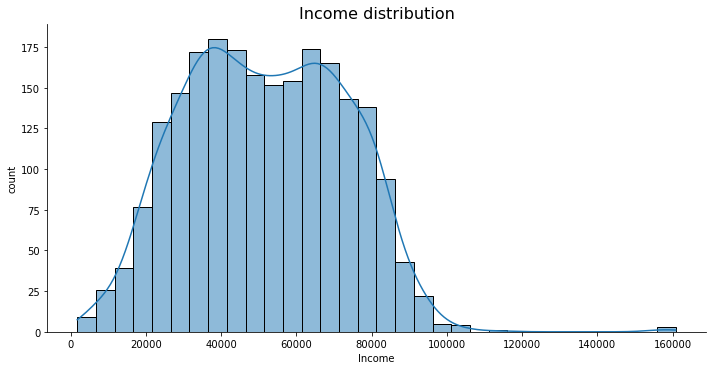

```python
# Plotting displot for income

sns.displot(df['Income'], kde = True, height = 5, aspect = 2)

plt.title('Income distribution', size = 16)

plt.ylabel('count');
```

**Observations:**

- After treating outliers, the distribution for the income variable is close to a normal distribution with very few extreme observations to the right.
- We will replace the missing values for the income variable with the median and not the mean, as the variable is slightly skewed to the right.

```python
# Filling null values with median

df['Income'].fillna(df.Income.median(), inplace = True)
```

### **Analyzing all the campaigns**

### **Question 2: Write your observations on acceptance rate for each campaign given in the below plot. (4 Marks)**

**Let's find out what is the acceptance rate for each campaign?**

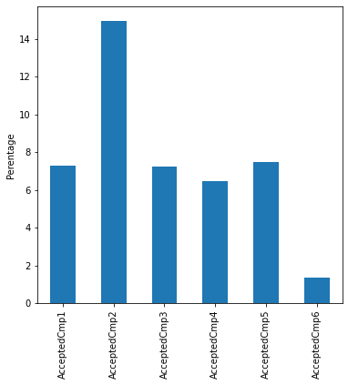

```python
# PLotting the % acceptance for every campaign

Camp_cols = ['AcceptedCmp1', 'AcceptedCmp2', 'AcceptedCmp3', 'AcceptedCmp4', 'AcceptedCmp5', 'AcceptedCmp6']

success_campaign = (df[Camp_cols].sum()/df.shape[0]) * 100

# Plot
success_campaign.plot(kind = 'bar', figsize = (6, 6))

plt.ylabel("Perentage")

plt.show()
```

**Observations:**___****

- AcceptedCmp2 has the highest acceptance percentage.
- AcceptedCmp6 has the lowest acceptance percentage.
- Other campaigns had relatively similar acceptance rate.

### **Let's analyze what kind of customer are accepting campaigns?**

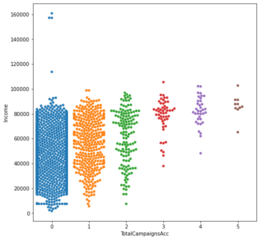

```python
plt.figure(figsize = (8, 8))

sns.swarmplot(x = 'TotalCampaignsAcc', y = 'Income', data = df)

plt.show()
```

**Observation:**

- Higher the income, the higher the number of campaigns accepted.

```python
# Let's see the mean income of customers
df.Income.mean()
```

```
51762.59811827957
```

### **Question 3: Write your observations on acceptance rate for each campaign according to the income level. (7 Marks)**

The mean income of customers is close to 52K. Let's divide the income into 2 segments of income>52k and income<52k and check the acceptance rate in each segment.

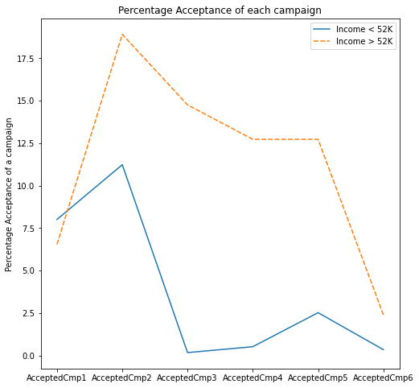

```python
# Making DataFrames of customers having income <52k and >52K
df1 = df[df.Income < 52000]

df2 = df[df.Income > 52000]

Camp_cols = ['AcceptedCmp1', 'AcceptedCmp2', 'AcceptedCmp3', 'AcceptedCmp4', 'AcceptedCmp5', 'AcceptedCmp6']

# Calculating success rate of each campaign for both segments
success_campaign1 = pd.DataFrame((df1[Camp_cols].sum()/df1.shape[0]) * 100, columns = ['Income < 52K'])

success_campaign2 = pd.DataFrame((df2[Camp_cols].sum()/df2.shape[0]) * 100, columns = ['Income > 52K'])

new_df = pd.concat([success_campaign1, success_campaign2], axis = 1)

# Plot
plt.figure(figsize = (8, 8))

sns.lineplot(data = new_df)

plt.title("Percentage Acceptance of each campaign")

plt.ylabel("Percentage Acceptance of a campaign")

plt.show()
```

**Observations:**

Let's find out who has accepted the last campaign and what could be the reason?

```python
df[df['AcceptedCmp6'] == 1].shape
```

```
(30, 31)
```

- There are only 30 customers who have accepted the last campaign.
- Let's check if these customers are new or if they have accepted previous campaigns as well.

```python
grouped2 = df.groupby('AcceptedCmp6').mean()['TotalCampaignsAcc']

grouped2
```

```
AcceptedCmp6
0    0.404632
1    3.633333
Name: TotalCampaignsAcc, dtype: float64
```

**Observations:**

- We know that the maximum number of campaigns any customer has accepted is 5.
- We can observe that the value for TotalCampaignsAcc is ~3.6 for customers who have accepted the last campaign.
- This implies that these 30 customers are those loyal customers who have been accepting most of the campaigns.

### **It could be that different campaigns are focused on a different set of products. Let's check if the product preference for those who accepted the campaigns is different from those who didn't, using the amount spent and the number of purchases**

Let's define a function that will take the column name for the product as the input and will generate the barplot for every campaign and the average amount spent on a product.

```python
def amount_per_campaign(columns_name):
    p1 = pd.DataFrame(df.groupby(['AcceptedCmp1']).mean()[columns_name]).T

    p2 = pd.DataFrame(df.groupby(['AcceptedCmp2']).mean()[columns_name]).T

    p3 = pd.DataFrame(df.groupby(['AcceptedCmp3']).mean()[columns_name]).T

    p4 = pd.DataFrame(df.groupby(['AcceptedCmp4']).mean()[columns_name]).T

    p5 = pd.DataFrame(df.groupby(['AcceptedCmp5']).mean()[columns_name]).T

    p6 = pd.DataFrame(df.groupby(['AcceptedCmp6']).mean()[columns_name]).T

    pd.concat([p1, p2, p3, p4, p5, p6], axis = 0).set_index([Camp_cols]).plot(kind = 'line', figsize = (8, 8))

    plt.ylabel('Average amount spend on' + ' ' + columns_name)

    plt.show()
```

#### Use the function defined above to generate barplots for different purchasing Products

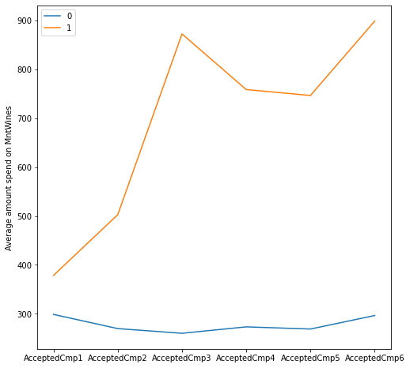

```python
# Here is an example showing how to use this function on the column MntWines
amount_per_campaign('MntWines')
```

**Observation:**

- For the customers accepting campaign 3, 4, 5, and 6, the average amount spent on wine is quite high.

### **Question 4: Write the code and your observations on average amount spent on different products across all campaigns. (7 Marks)**

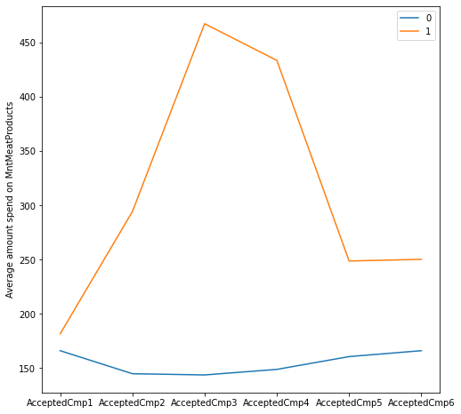

```python
# Meat products

# Call the function amount_per_campaign for MntMeatProducts
amount_per_campaign('MntMeatProducts')
```

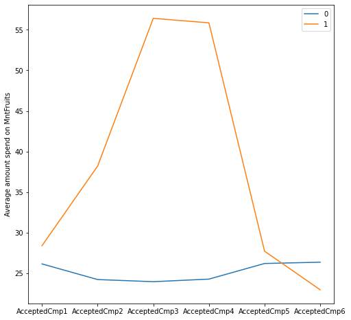

```python
# Fruit products

# Call the function amount_per_campaign for MntFruits
amount_per_campaign('MntFruits')
```

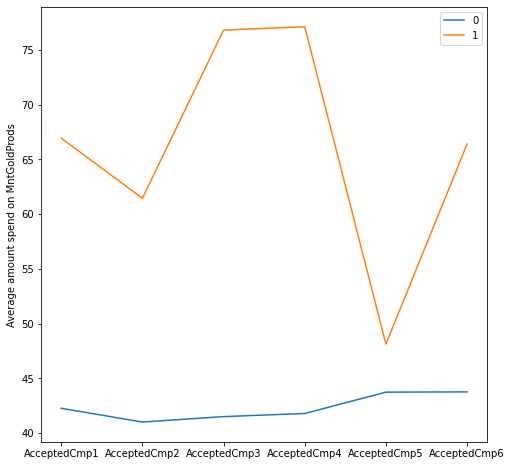

```python
# Gold products

# Call the function amount_per_campaign for MntGoldProds
amount_per_campaign('MntGoldProds')
```

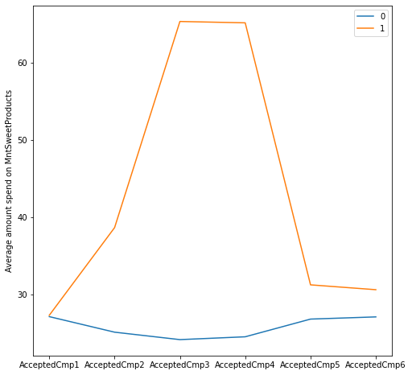

```python
# Sweet products

# Call the function amount_per_campaign for MntSweetProducts
amount_per_campaign('MntSweetProducts')
```

**Observations:**__****

- For the customers accepting campaign 3, 4, the average amount spent on all meat, fruit, gold, and sweet are all high.
- For Fruit, customers who accepted campaign 6 once, spent less on MntFruits, meaning they might have been not really satisfied with the product.
- For Gold, customers who accepted campaign 1 and 6 also spent a lot was high, on top of 3 and 4.
- For the all customers who purchased more than one of those products, wine and meat have the highest spending number

**We have analyzed the relationship between campaigns and different products. Now, let's see the relationship of campaigns with different purchasing channels.**

### **Relationship of campaigns with different purchasing channels**

We have a defined a function which will take the column name of the channel as the input and will generate the barplot for every campaign and average purchase made through that channel if the campaign is accepted.

```python
def Purchases_per_campaign(columns_name):
    dp1 = pd.DataFrame(df.groupby(['AcceptedCmp1']).mean()[columns_name]).T

    dp2 = pd.DataFrame(df.groupby(['AcceptedCmp2']).mean()[columns_name]).T

    dp3 = pd.DataFrame(df.groupby(['AcceptedCmp3']).mean()[columns_name]).T

    dp4 = pd.DataFrame(df.groupby(['AcceptedCmp4']).mean()[columns_name]).T

    dp5 = pd.DataFrame(df.groupby(['AcceptedCmp5']).mean()[columns_name]).T

    dp6 = pd.DataFrame(df.groupby(['AcceptedCmp6']).mean()[columns_name]).T

    pd.concat([dp1, dp2, dp3, dp4, dp5, dp6], axis = 0).set_index([Camp_cols]).plot(kind = 'line', figsize = (8, 8))

    plt.ylabel('Average' + ' ' + columns_name)

    plt.show()
```

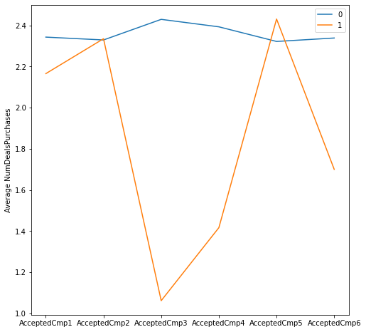

```python
# Here is an example showing how to use this function on the column NumDealsPurchases
Purchases_per_campaign('NumDealsPurchases')
```

**Observation:**

- For the customers accepting campaign 3, 4, and 6, the average number of deals purchase is quite low.

### **Question 5: Write the code and your observations on average number of purchases from different channels across all campaigns. (7 Marks)**

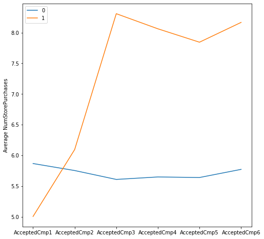

```python
# Store purchase

# Call the function Purchases_per_campaign for NumStorePurchases
Purchases_per_campaign('NumStorePurchases')
```

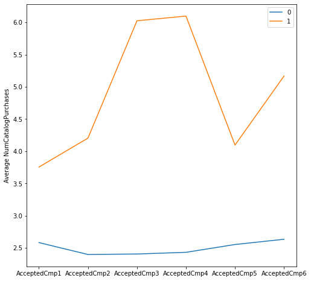

```python
# Catalog purchase

# Call the function Purchases_per_campaign for NumCatalogPurchases
Purchases_per_campaign('NumCatalogPurchases')
```

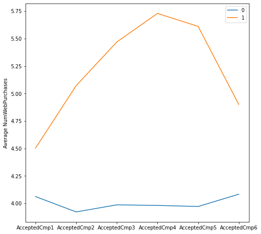

```python
# Web purchases

# Call the function Purchases_per_campaign for NumWebPurchases
Purchases_per_campaign('NumWebPurchases')
```

**Observations:**___****

- Customers who accepted campaign 3,4,5, and 6 had high average number of store purchases, and customers who accepted camapaign 1 had lowest and even lower number of store purchases, after buying it.
- Customers who accepted campaign 3,4, and 6 has high number of catalog purchases.
- Customers who accepted campaign 4 had highest number of web purchases, and 5,3,2,6,1 following

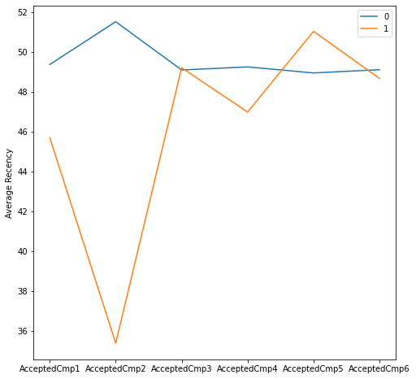

```python
# Recency

Purchases_per_campaign('Recency')
```

**Observation:**

- Average recency of the customers who accepted campaign 2 is quite low, which implies that campaign 2 was accepted by the customers who recently purchased an item.

We have analyzed the relationship between campaigns and numerical variables. Let's check the relationship of campaigns with different categorical variables.

We will check the percentage acceptance of each campaign with respect to each category in the categorical variable. The percentage acceptance is calculated as number of customers who have accepted the campaign to the total number of customers.

```python
def Cat_Campaign_Relation(df, column_name):
    e1 = (df.groupby([column_name]).sum()['AcceptedCmp1']/df.groupby([column_name]).count()['AcceptedCmp1'])

    e2 = (df.groupby([column_name]).sum()['AcceptedCmp2']/df.groupby([column_name]).count()['AcceptedCmp2'])

    e3 = (df.groupby([column_name]).sum()['AcceptedCmp3']/df.groupby([column_name]).count()['AcceptedCmp3'])

    e4 = (df.groupby([column_name]).sum()['AcceptedCmp4']/df.groupby([column_name]).count()['AcceptedCmp4'])

    e5 = (df.groupby([column_name]).sum()['AcceptedCmp5']/df.groupby([column_name]).count()['AcceptedCmp5'])

    e6 = (df.groupby([column_name]).sum()['AcceptedCmp6']/df.groupby([column_name]).count()['AcceptedCmp6'])

    df_new = pd.concat([e1, e2, e3, e4, e5, e6], axis =  1).T

    plt.figure(figsize = (8, 8))

    sns.lineplot(data = df_new, markers = True, linewidth = 2)

    plt.ylabel('Percentage Acceptance')

    plt.show()
```

[figure not shown]

```python
# Here is an example showing how to use this function on the column Education
Cat_Campaign_Relation(df, 'Education')
```

**Observations:**

- More than 20% of the customers with Ph.D. have accepted campaign 2.
- Customers with basic education have only accepted campaign 1 and 2.
- Except customers with basic education level, all education levels follow the same trend.

### **Question 6: Write the code and your observations on percentage acceptance for different categorical variables across all campaigns. (7 Marks)**

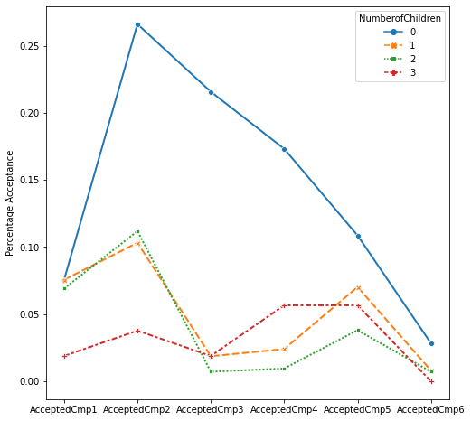

```python
# NumberofChildren

# Call the function Cat_Campaign_Relation for NumberofChildren
Cat_Campaign_Relation(df, 'NumberofChildren')
```

```python
# Let's filter the observations with 'Others' category as they are only 4 such observations
df_rest = df[df.Marital_Status != 'Others']
```

[figure not shown]

```python
# Call the function Cat_Campaign_Relation for Marital_Status with DataFrame
Cat_Campaign_Relation(df, 'Marital_Status')
```

**Observations:**___****

- Group that does not have any children tends to have higher percentage of acceptance than every other group that have children.
- When you have children of 3, the acceptance rate of campaign 2 decreases, and aceptnace for campaign 4 increases.
- Regardless of number of children, people had relatively high acceptance rate for campaign 2 and 5, and low acceptance rate for campaign 6.
- When Marital status is absurd, the group have much higher acceptance rate of campaign 3 and 4.

Let's check the percentage acceptance for each country.

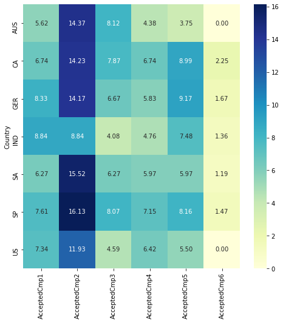

```python
# Let's filter the observations for 'ME' country as they are only 3 such observations
df_not_mexico = df[df.Country != 'ME']

# Plot
plt.figure(figsize = (8, 8))

sns.heatmap((df_not_mexico.groupby('Country').sum()[Camp_cols]/df_not_mexico.groupby('Country').count()[Camp_cols]) * 100, annot = True, fmt = '0.2f', cmap = "YlGnBu")
```

- We observed earlier that Spain, South Africa, Canada, and Australia have the highest percentage of customers. These countries are the main drivers of each campaign as the percentage of acceptance is high for these countries.
- We can see that in the 6th campaign, all main drivers have a very low percentage acceptance with no acceptance from Australia.

### **Check the product preferences by customers**

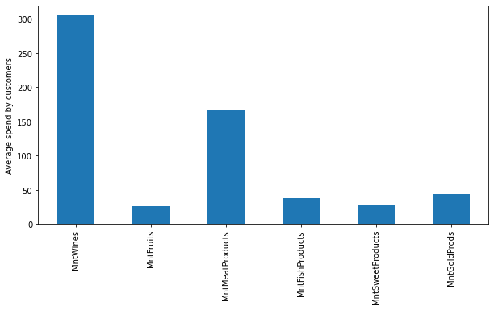

```python
# Creating a list which contains name of all products

mnt_cols = [col for col in df.columns if 'Mnt' in col]

spending = df[mnt_cols].mean(axis = 0)

spending.plot(kind = 'bar', figsize = (10, 5))

plt.ylabel("Average spend by customers")

plt.show()
```

**Observation:**

- The mean amount spent by customers in the last 2 years is the highest for wines followed by the meat products.

Let's check if the product preferences are similar for different types of customers. We will calculate the percentage amount spent by customers on a product for each category with respect to the total spending by customers belonging to that category.

```python
def amount_per_category(df, column_name):
    df_new1 = ((df.groupby([column_name]).sum()[mnt_cols].T)/df.groupby([column_name]).sum()['Total_Spending'])

    plt.figure(figsize = (10, 8))

    sns.heatmap(df_new1.T, annot = True, cmap = "YlGnBu")

    plt.show()
```

[figure not shown]

```python
# Plot showing the percentage of total spending on different products by a group of customers having the same education level

amount_per_category(df, 'Education')
```

**Observations:**

- Customers with Ph.D. spend ~60% of their total spending on wines.
- Customers with Graduation and Master's spends ~45-50% of their total spending on wines.
- Customers with Graduation and Master's spends ~27-29% of their total spending on meat.
- Customers with Ph.D. spend ~25% of their total spending on meat.
- Customers having education level Master or Ph.D. spend ~80% on meat and wines.
- Customers with basic education spend more on Fruits, Fish, Sweet, and Gold products.

### **Question 7: Write the code and your observations on the percentage amount spent on different products for each category of the mentioned categorical variables. (7 Marks)**

[figure not shown]

```python
# Call the function amount_per_category for Marital_Status with DataFrame df_rest

amount_per_category(df_rest, 'Marital_Status')
```

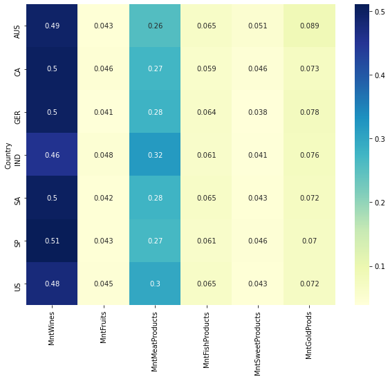

```python
# Call the function amount_per_category for Country with DataFrame df_not_mexico

amount_per_category(df_not_mexico, 'Country')
```

**Observations:**___****

- Customers who has marital status of alone spends 72% of their total spending on Wines
- Except the group with marital status of Absurd, most groups regardless of their martial status spends around half 50% of their total spending on Wines
- Second highest column of spending for most marital groups are Meat products
- All of the country groups spends around half 50% of their total spending on Wines
- Second highest column of spending for all country groups is Meat products

### **Check different channel performances**

Let's calculate the percentage of purchases for all the channels.

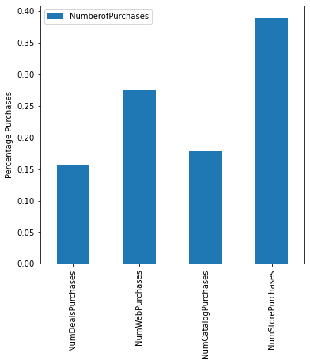

```python
# List of columns for channels

channel_cols = [col for col in df.columns if 'Purchases' in col]

# Making DataFrame of columns having purchase and taking sum of them
channels = pd.DataFrame(df[channel_cols].sum()/df.Total_Purchase.sum(), columns = ['NumberofPurchases'])

# Plot
channels.plot(kind = 'bar', figsize = (6, 6))

plt.ylabel("Percentage Purchases")

plt.show()
```

**Observations:**

- We can see that most purchases are from the stores followed by web purchases.
- The number of deal purchases and catalog purchases are low.

### **Question 8: Write your observations on the percentage purchases from different channels for different categories of the income_cat column. (4 Marks)**

Let's check how number of purchases via different channels varies for different income bins?

```python
# Binning the income column
df['income_cat'] = pd.qcut(df.Income, q = [0, 0.25, 0.50, 0.75, 1], labels = ['low', 'medium', 'high', 'very_high'])
```

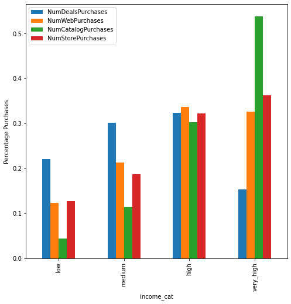

```python
group = df.groupby('income_cat').sum()[channel_cols]

(group/group.sum()).plot(kind = 'bar', figsize = (8, 8))

plt.ylabel("Percentage Purchases")

plt.show()
```

**Observations:**__****

- As your income increases, the group tends to increase in their percentage of purchases overall.
- Number of deals purhcases stays relatively high for low. medium, and high income groups, except it drops drastically for very-high income group
- Number of catalog purchases have most correlation with the income level, as the percentage of purchases consistently increases as the income level of the group increases also.

### **We can also visualize the correlation between purchases from different channels and the income of the customer.**

### **Question 9: Find the correlation matrix for the columns mentioned below and visualize the same using heatmap. (3 Marks)**

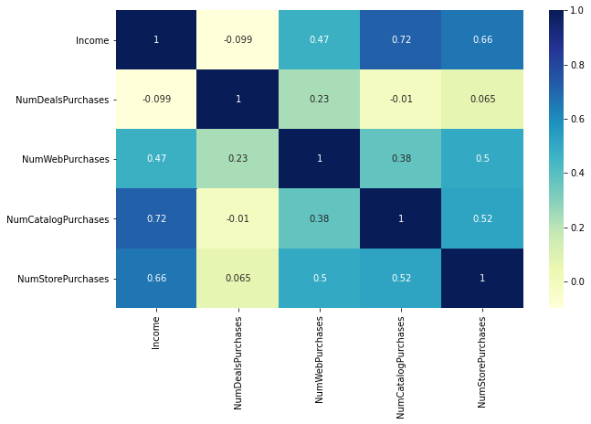

```python
corr = df[['Income', 'NumDealsPurchases', 'NumWebPurchases', 'NumCatalogPurchases', 'NumStorePurchases' ]].corr()

plt.figure(figsize = (10, 6))

sns.heatmap(corr, annot = True, cmap = "YlGnBu")# Remove the blank line and write your code

plt.show()
```

**Observations:*__***

- Income has the most correlation with number of web purchases, number of catalog purchases, and number of store purchases.
- Number of store purchases, number of web purchases, and number of catalog purchases also have relatively high 0.5 of correlation

As we know from our analysis, we have done so far, customers with high income, number of children, and amount spent on wines are the important factors. Let's try to come up with a new customer profile based on these 3 attributes and check what would be the acceptance rate for that customer profile.

```python
# Customers with high income
df3 = df[df.Income > 52000]

# Among customers with high income, selecting customers with high spending on wines
df4 = df3[df3.MntWines > df3.MntWines.mean()]

# Among customers with high income and high spending on wines, selecting customers with no children
new_profile = df4[df4.NumberofChildren == 0]
```

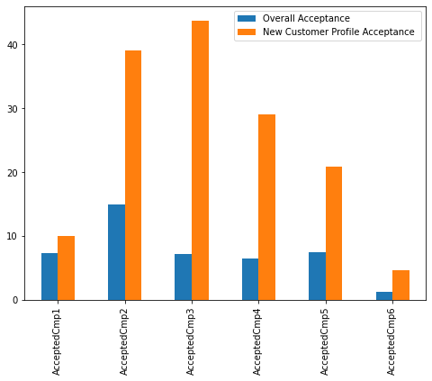

```python
# Calculating the success rate of each campaign for both segments
success_campaign3 = pd.DataFrame(success_campaign, columns = ['Overall Acceptance'])

success_campaign4 = pd.DataFrame((new_profile[Camp_cols].sum()/new_profile.shape[0]) * 100, columns = ['New Customer Profile Acceptance '])

# Plot
pd.concat([success_campaign3, success_campaign4], axis = 1).plot(kind = 'bar', figsize = (8, 6))

plt.title("")

plt.ylabel("")

plt.show()
```

**Observation:**

- Orange bars in the plot indicate that the acceptance rate would have been high for the new customer profile, i.e., income greater than the mean income, no kid at home, and amount spent on wines is greater than the mean amount spent on wines.

### **Question 10: Based on your analysis, write the conclusions and recommendations for the CMO to help make the next marketing campaign strategy. (10 Marks)**

## **Conclusion and Recommendations**

**Write your conclusion here**

- We have collected, organized, and looked at the data set, took out outliers, and null values.
- We have looked and analyzed many variables that may have been a factor of consumer analytics, such as age, total spending, income level, etc, to find ways to maximize our customer's conversion rate for each campaign.
- We have concluded that variables such as income level, spending, and number of children plays a significant role in their acceptance rate.
- High income level, high spending specifically on wine item, and less or 0 number of children had highest acceptance rate for our products, and it is shown in the last bar graph, comparing the overall acceptance rate for all of our customer base, versus the smaller specific targetted group of customers with high income level, high spending on wine, and 0 children.

**Write your recommendations here**

- As we have concluded, we know that targetted group of customers with high income level, high spending on wine, and 0 children had shown the highest acceptance rate for all 6 campaigns, especially 2, 3, and 4. Our campaign for the products need to be more appealing to this targetted group of people. It is important to understand that high income level, high spending on wine, and 0 children all relates to this targetted group of customer's life style. Our campaign needs to be more appealing as high class, authentic that tells them it is worth spending money on, with high income that they have earned, goes well with the high class with wine, especially when you do not have a children to spend those money on. It will not only be targetting them, but branding as something that even all other groups aspire to have, and dream of, when they reach higher income and want to enjoy the luxury, without other financial responsibilities such as children.